# Revista ECYS - Edición XXIX

Revista Ciencias, Sistemas y Tecnología

Edición XXIX · Escuela de Ingeniería en Ciencias y Sistemas · USAC

Inicio Índice Final Descargar PDF

[figure not shown]

Página 1 de 52

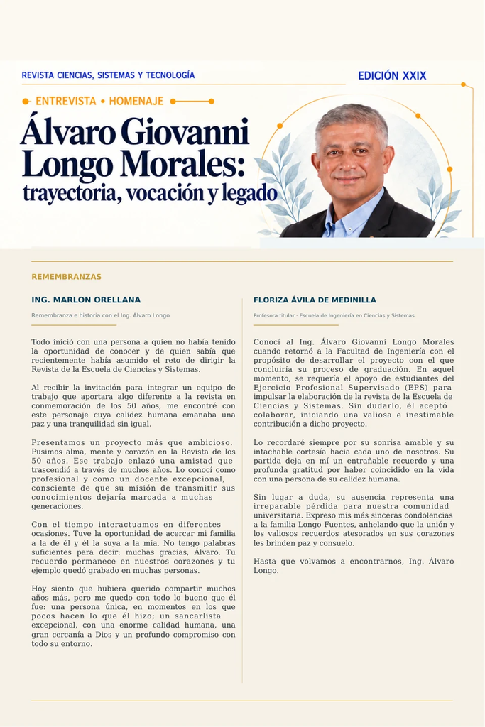

Página 2 de 52

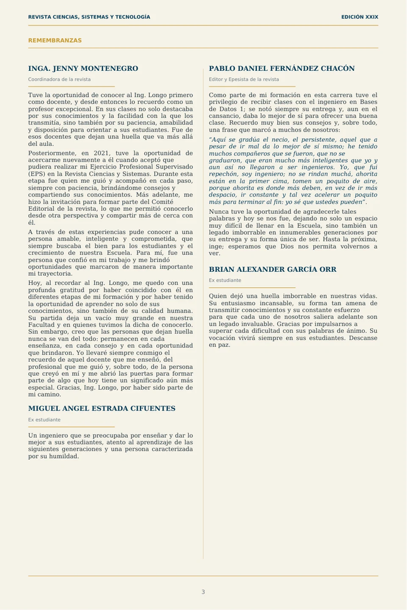

Página 3 de 52

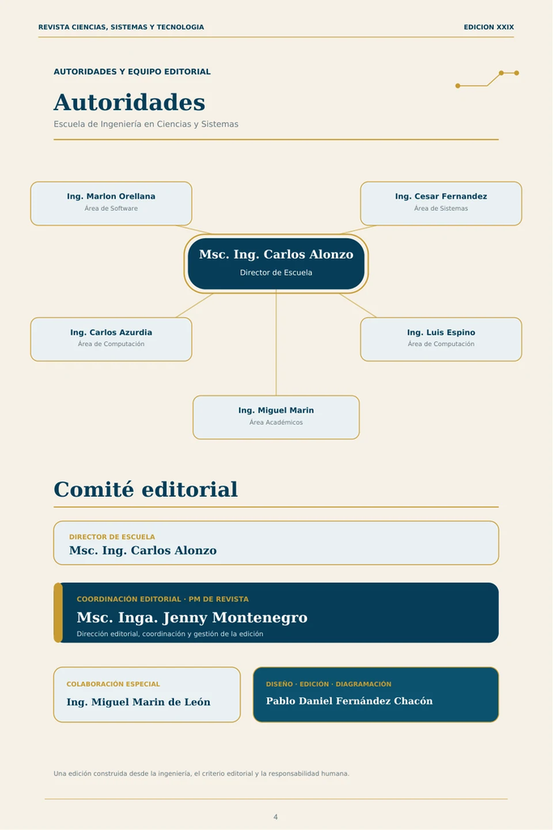

Página 4 de 52

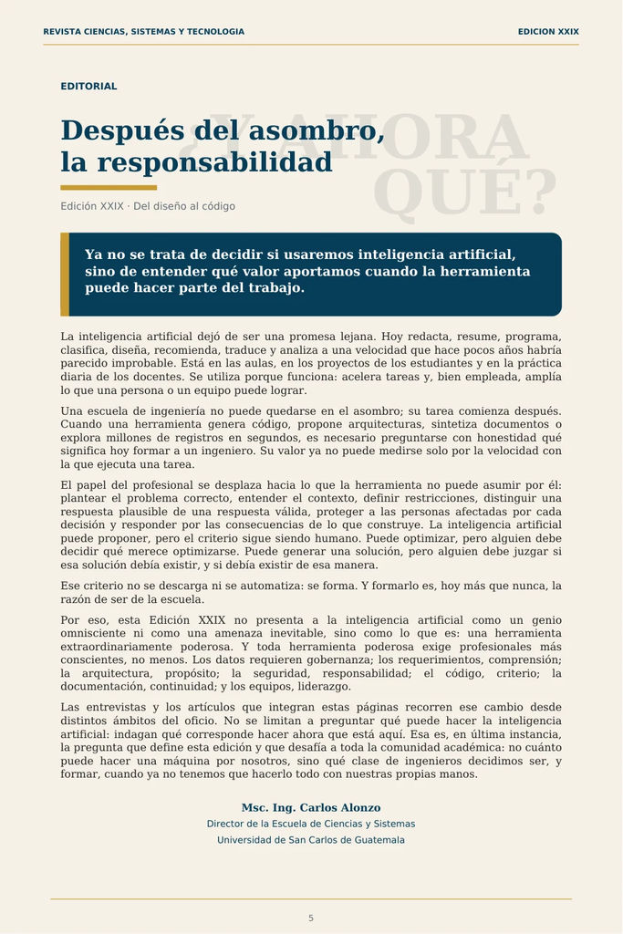

Página 5 de 52

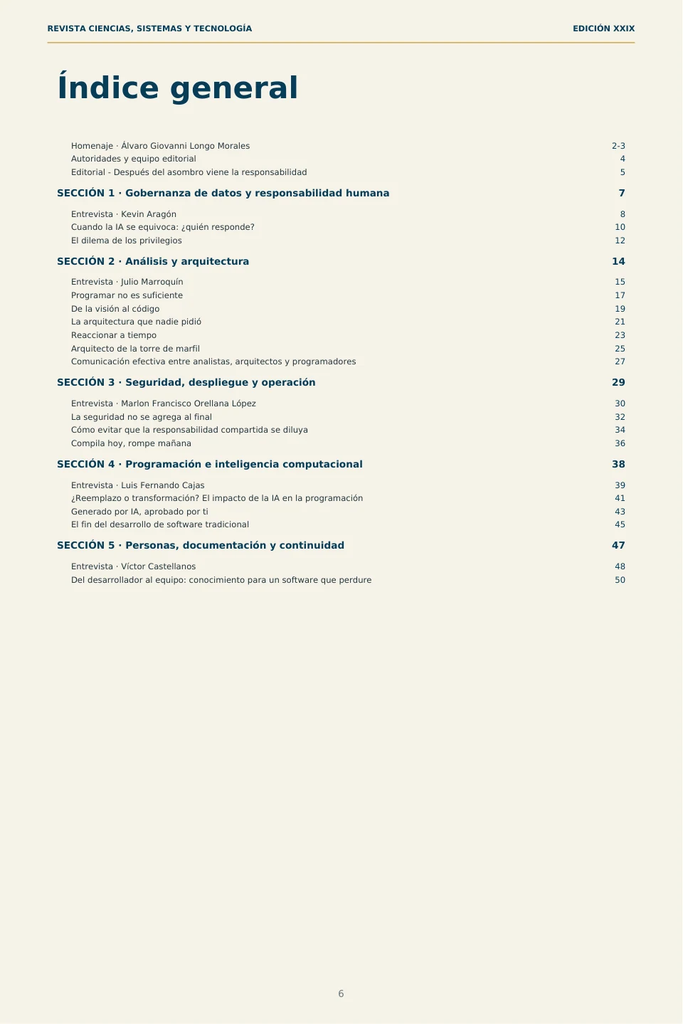

Página 6 de 52

[figure not shown]

Página 7 de 52

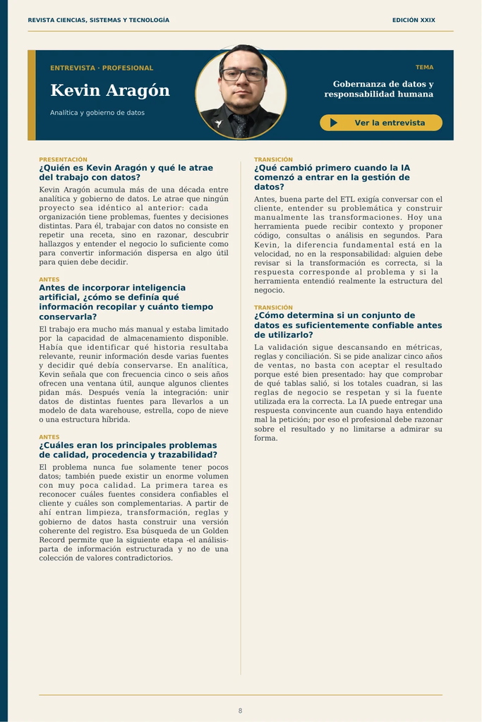

Página 8 de 52

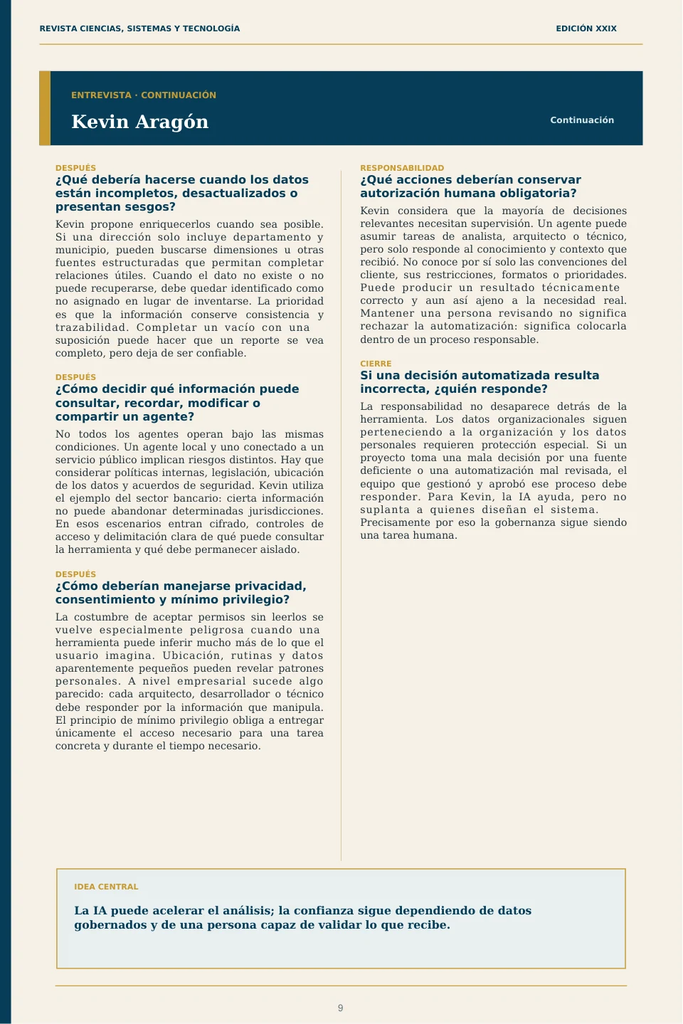

Página 9 de 52

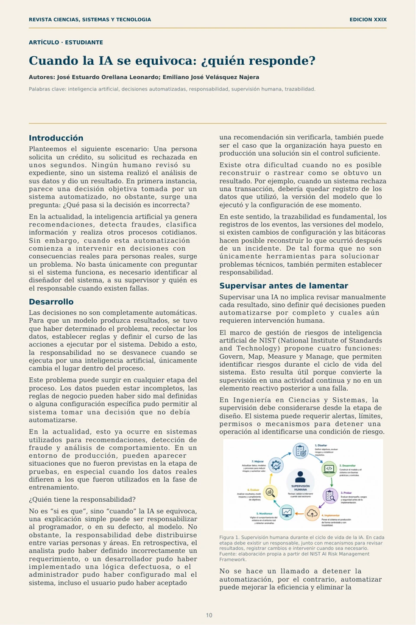

Página 10 de 52

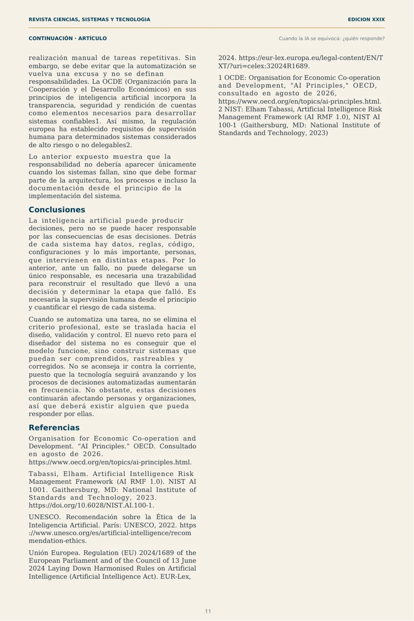

Página 11 de 52

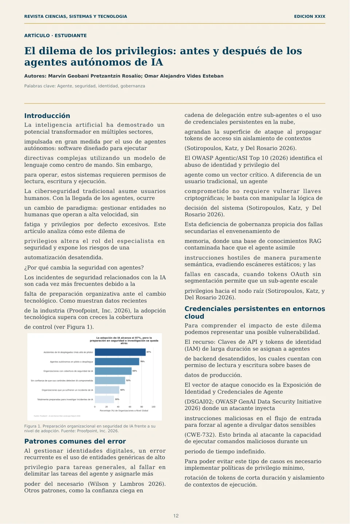

Página 12 de 52

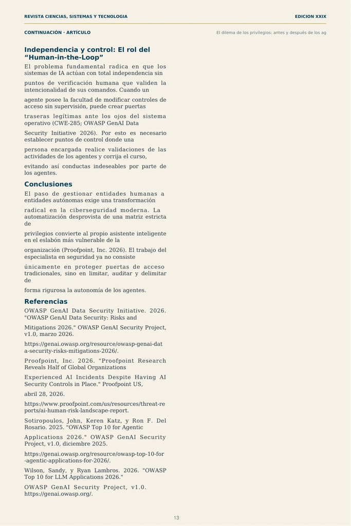

Página 13 de 52

[figure not shown]

Página 14 de 52

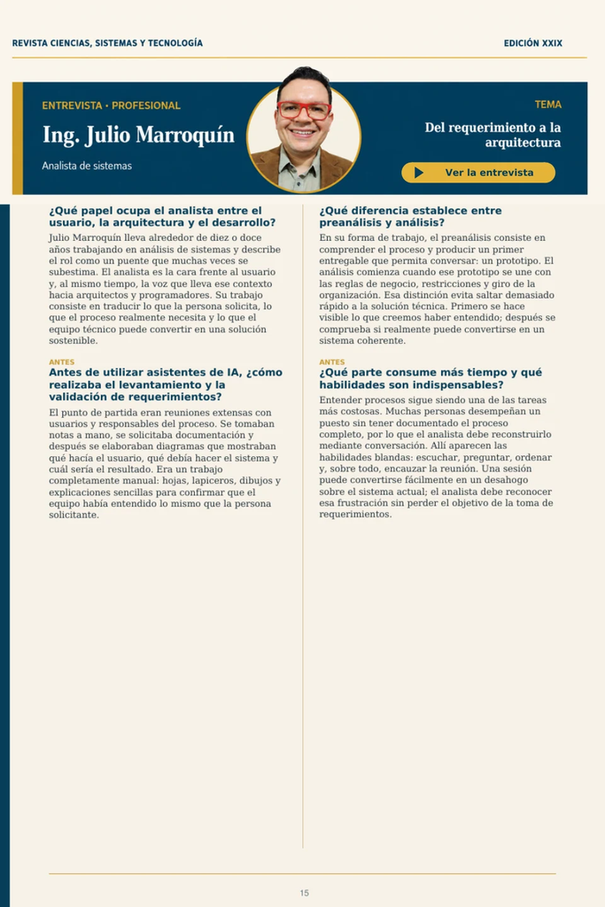

Página 15 de 52

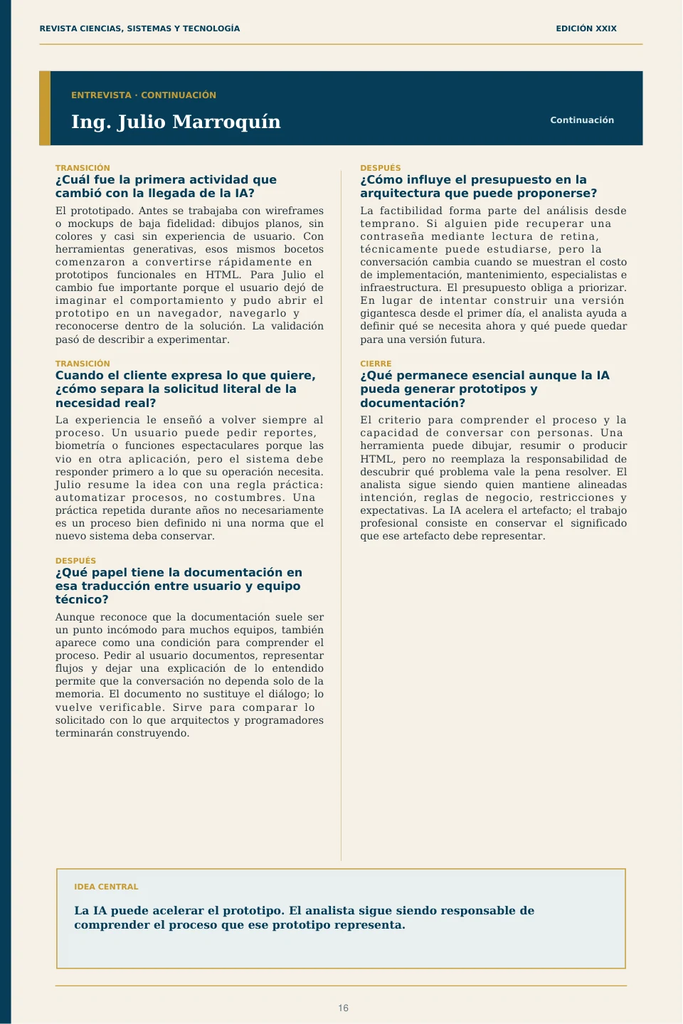

Página 16 de 52

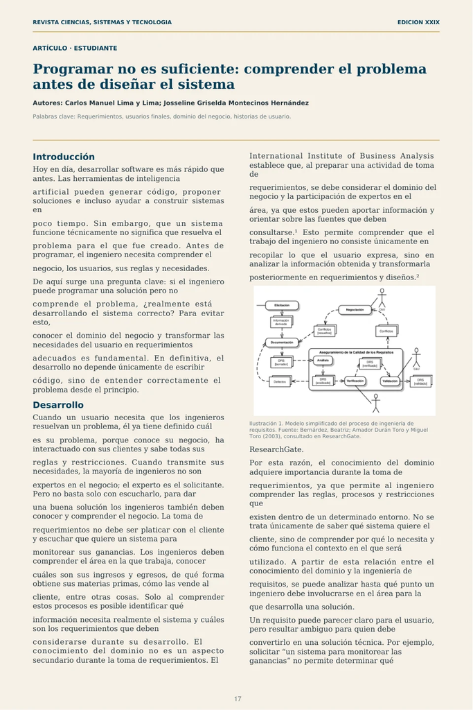

Página 17 de 52

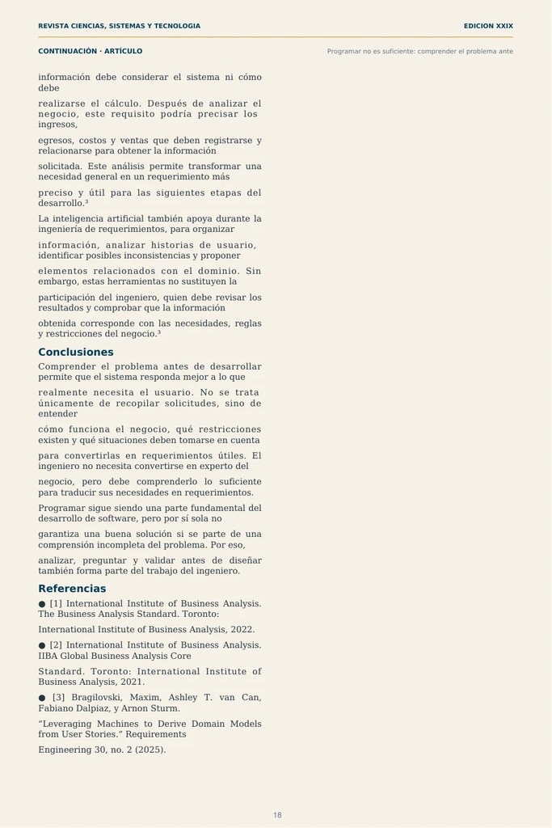

Página 18 de 52

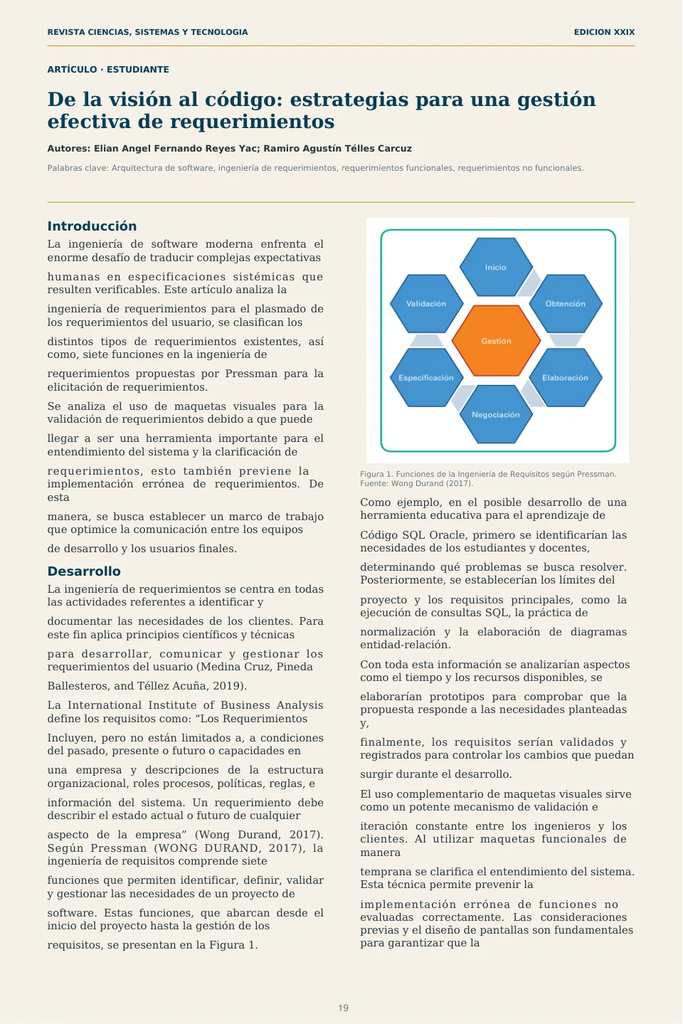

Página 19 de 52

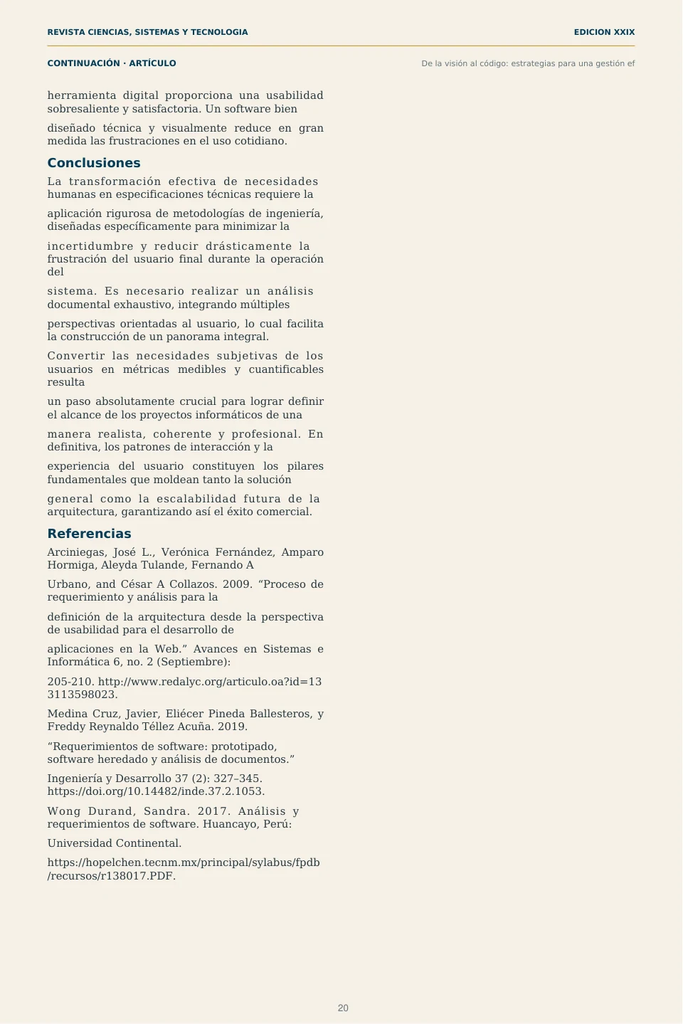

Página 20 de 52

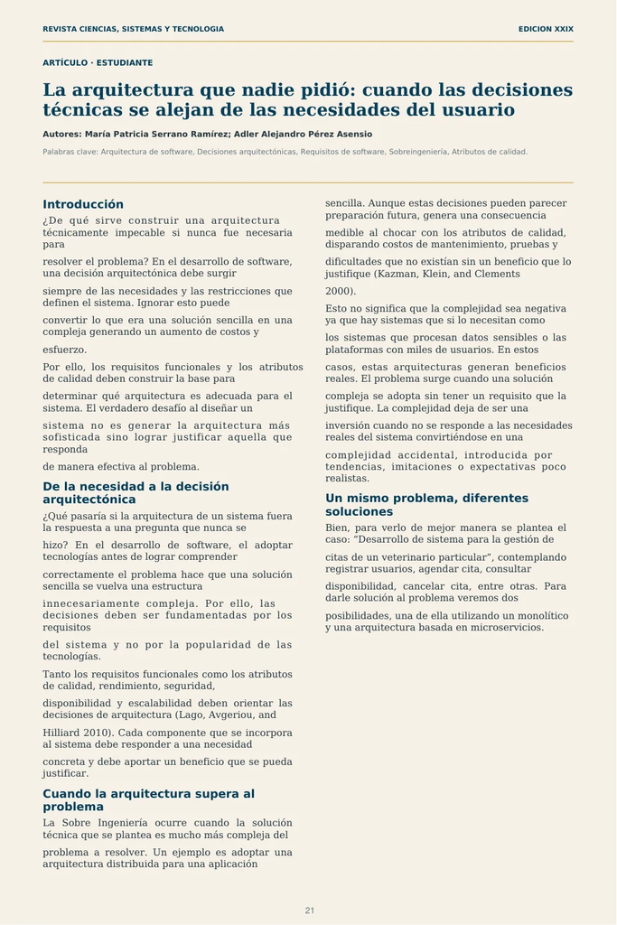

Página 21 de 52

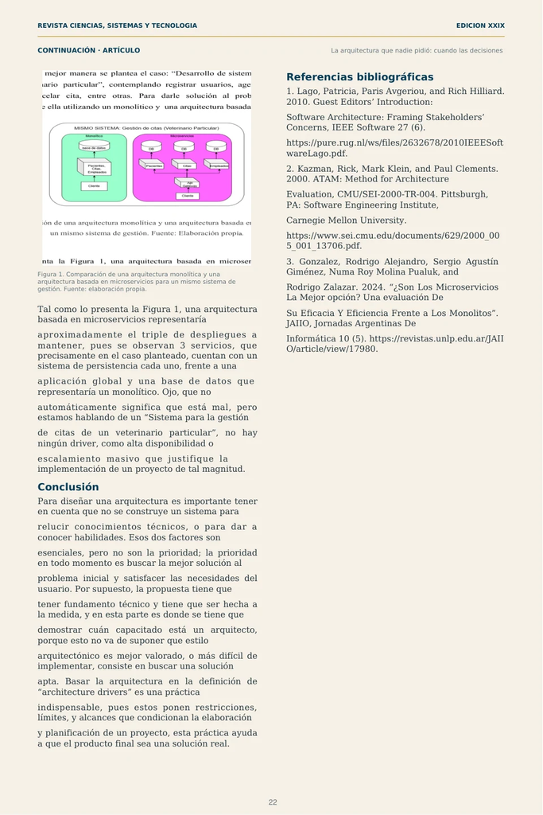

Página 22 de 52

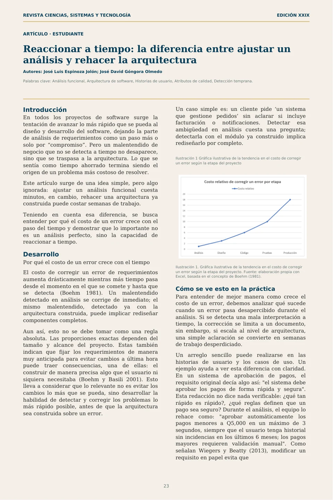

Página 23 de 52

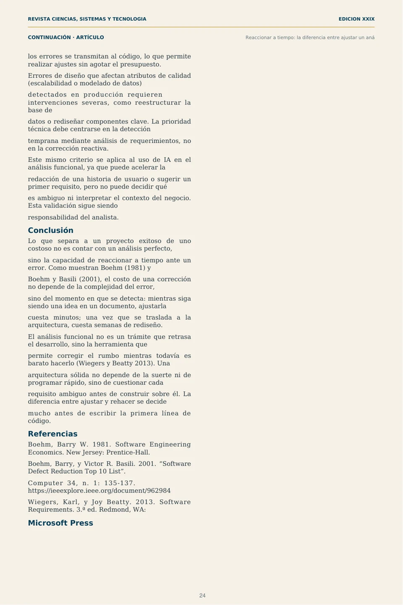

Página 24 de 52

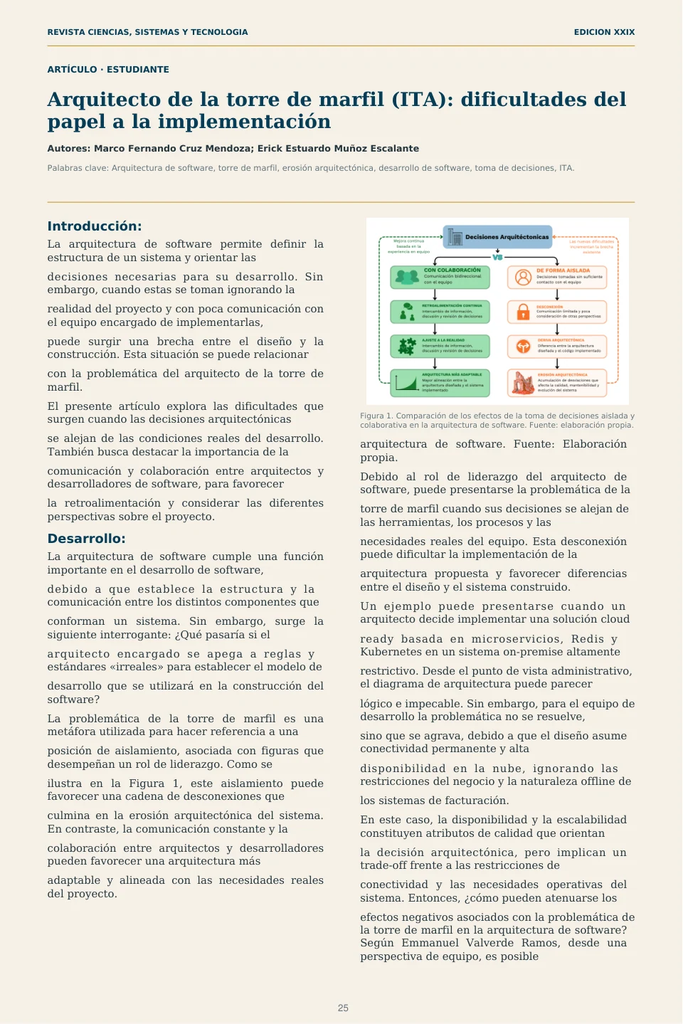

Página 25 de 52

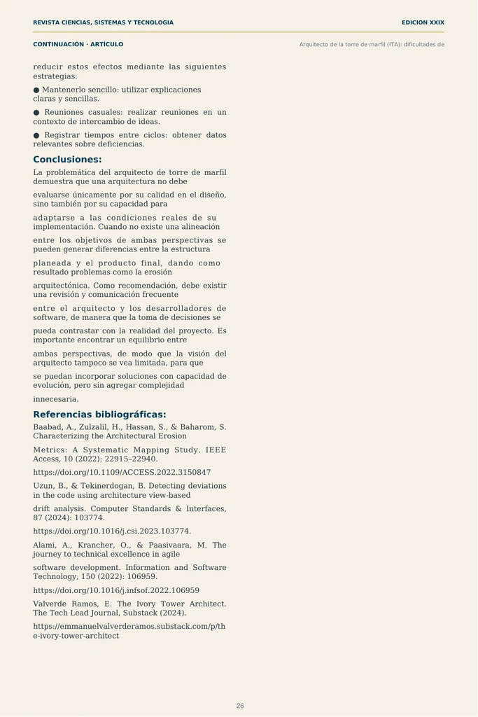

Página 26 de 52

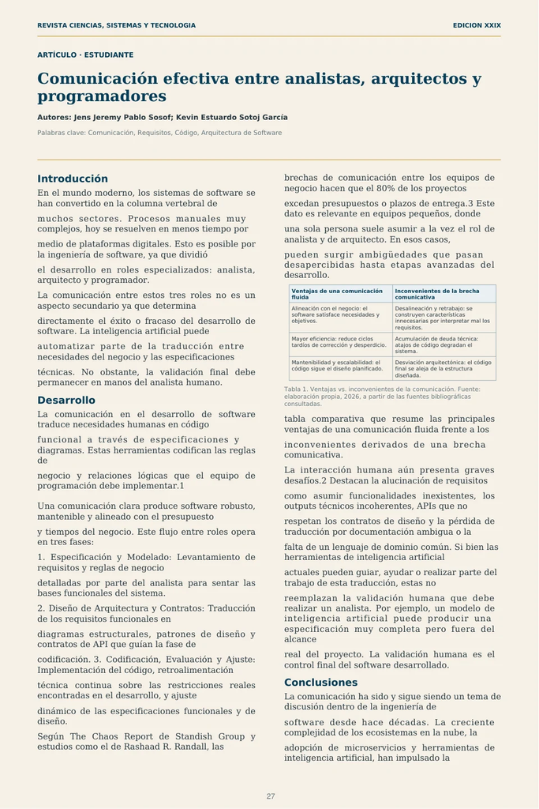

Página 27 de 52

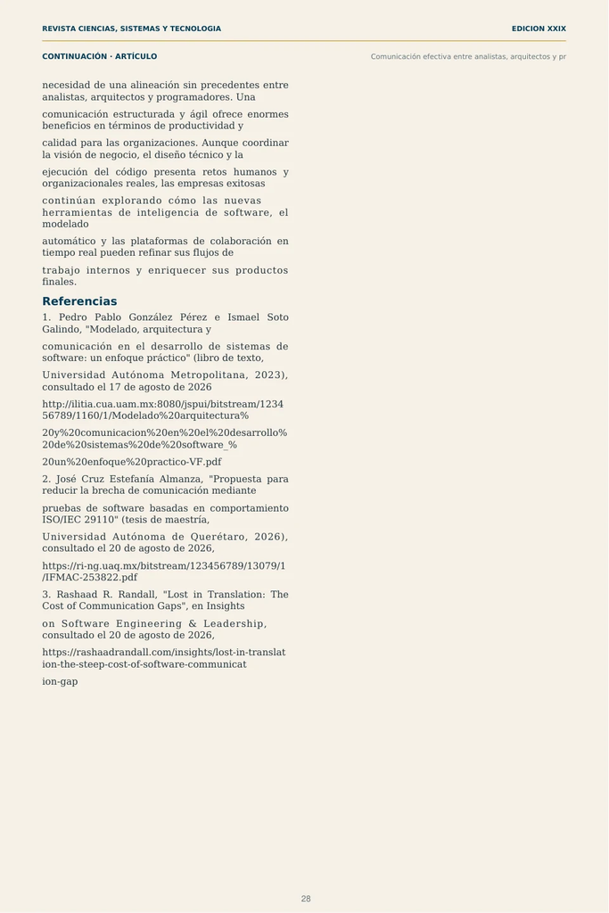

Página 28 de 52

[figure not shown]

Página 29 de 52

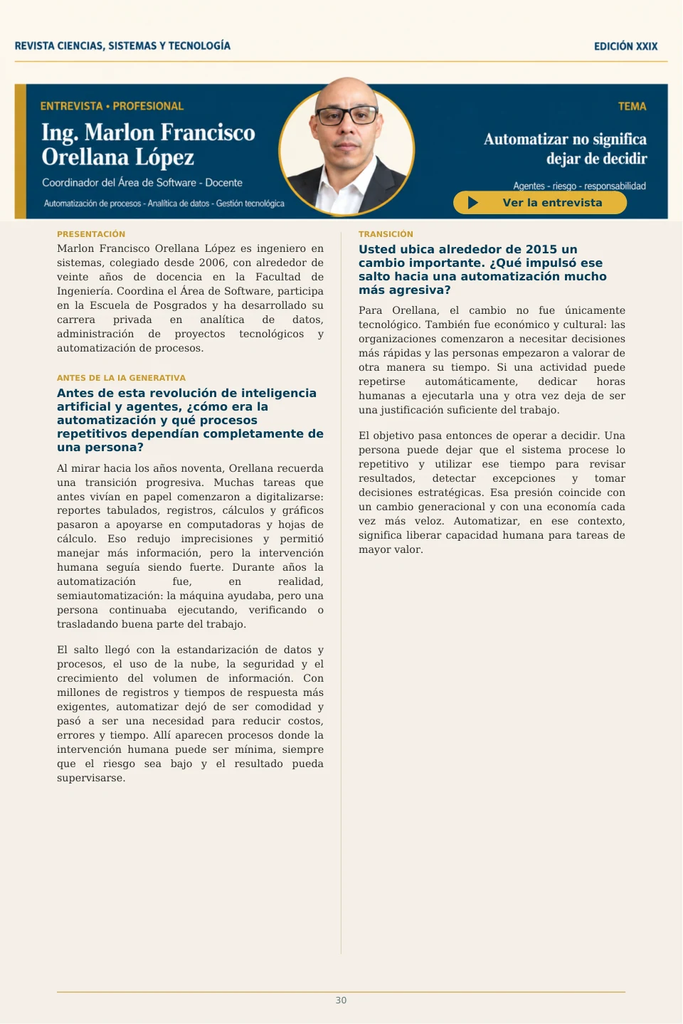

Página 30 de 52

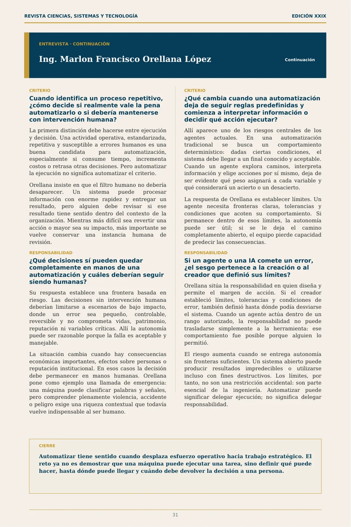

Página 31 de 52